# Using the Google Visualisation API with R

Markus Gesmann

googleVis project

Diego de Castillo

googleVis project

2011-12-01

Abstract

The [*googleVis*](https://CRAN.R-project.org/package=googleVis) package provides an interface between R and the Google Visualisation API to create interactive charts which can be embedded into web pages. The best known of these charts is probably the Motion Chart, popularised by Hans Rosling in his TED talks. With the [*googleVis*](https://CRAN.R-project.org/package=googleVis) package users can easily create web pages with interactive charts based on R data frames and display them either via the local R HTTP help server or within their own sites.

# Motivation

In 2006 Hans Rosling gave an inspiring talk at TED[^1] about social and economic developments in the world over the past 50 years, which challenged the views and perceptions of many listeners. Rosling had used extensive data analysis to reach his conclusions. To visualise his talk, he and his colleagues at [Gapminder](http://www.gapminder.org) had developed animated bubble charts, see Figure 1.

Rosling’s presentation popularised the idea and use of interactive charts, and as a result the software behind Gapminder was bought by Google and integrated as motion charts into their [Visualisation API](http://code.google.com/apis/visualization/documentation/index.html)[^2] one year later.

In 2010 Sebastián Pérez Saaibi (Saaibi 2010) presented at the R/Rmetrics Workshop on Computational Finance and Financial Engineering the idea to use Google motion charts to visualise R output with the [*rsp*](https://CRAN.R-project.org/package=rsp) package (Bengtsson 2011).

Inspired by those talks and the desire to use interactive data visualisation tools to foster the dialogue between data analysts and others, the authors of this article started the development of the [*googleVis*](https://CRAN.R-project.org/package=googleVis) package (Gesmann and D. de Castillo, n.d.).

# Google Visualisation API

The Google Visualisation API allows users to create interactive charts as part of Google documents, spreadsheets and web pages. This text will focus on the usage of the API as part of web sites.

The [Google Public Data Explorer](http://www.google.com/publicdata/home) (http://www.google.com/publicdata/home) provides a good example, demonstrating the use of interactive charts and how they can help to analyse data. The charting data can either be embedded into the html file or read dynamically. The key to the Google Visualisation API is that the data is structured in a “[DataTable](http://code.google.com/apis/visualization/documentation/reference.html)”, and this is where the [*googleVis*](https://CRAN.R-project.org/package=googleVis) package helps. It uses the functionality of the [*rjsonio*](https://CRAN.R-project.org/package=rjsonio) package (Temple Lang 2011) to transform R data frames into [JSON](http://www.json.org/)[^3] objects as the basis for a DataTable.

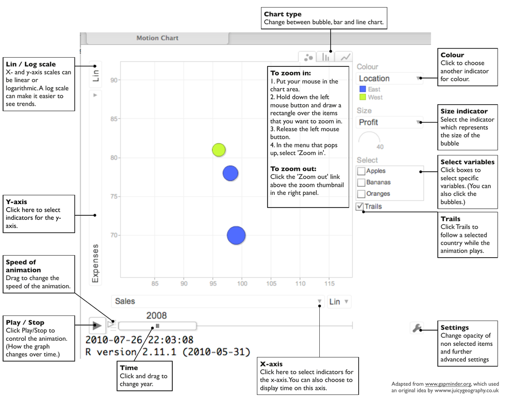

Figure 1: Overview of a Google Motion Chart. Screenshot of the output of plot(gvisMotionChart(Fruits, idvar = ‘Fruit’, timevar = ‘Year’))

As an example, we will look at the html code of a motion chart from Google’s visualisation [gallery](http://code.google.com/apis/visualization/documentation/gallery/motionchart.html), which generates output similar to Figure 1:

```r
 1 <html>
 2 <head>
 3  <script type="text/javascript"
 4    src="http://www.google.com/jsapi">
 5  </script>
 6  <script type="text/javascript">
 7    google.load('visualization', '1',
 8     {'packages':['motionchart']});
 9   google.setOnLoadCallback(drawChart);
10   function drawChart() {
11   var data=new google.visualization.DataTable();
12   data.addColumn('string', 'Fruit');
13   data.addColumn('date', 'Date');
14   data.addColumn('number', 'Sales');
15   data.addColumn('number', 'Expenses');
16   data.addColumn('string', 'Location');
17   data.addRows([
18   ['Apples',new Date(1988,0,1),1000,300,'East'],
19   ['Oranges',new Date(1988,0,1),1150,200,'West'],
20   ['Bananas',new Date(1988,0,1),300,250,'West'],
21   ['Apples',new Date(1989,6,1),1200,400,'East'],
22   ['Oranges',new Date(1989,6,1),750,150,'West'],
23   ['Bananas',new Date(1989,6,1),788,617,'West']
24   ]);
25   var chart=new google.visualization.MotionChart(
26     document.getElementById('chart_div'));
27   chart.draw(data, {width: 600, height:300});
28  }
29  </script>
30 </head>
31 <body>
32 <div id="chart_div"
33      style="width:600px; height:300px;">
34 </div>
35 </body>
36 </html>
```

The code and data are processed and rendered in the browser and is not submitted to any server[^4].

You will notice that the above html code has five generic parts[^5]:

- references to Google’s AJAX (l. 4) and Visualisation API (ll. 7–8),
- data to visualise as a DataTable (ll. 11–24),
- an instance call to create the chart (ll. 25–26),
- a method call to draw the chart including options, shown here as width and height (l. 27),
- an HTML `<div>` element to add the chart to the page (ll. 32–34).

These principles hold true for most of the interactive charts of the Google Visualisation API.

However, before you use the API you should read the [Google Visualisation API Terms of Service](http://code.google.com/apis/visualization/terms.html)[^6] and the [Google Maps/Google Earth APIs Terms of Service](http://code.google.com/apis/maps/terms.html)[^7].

# The [*googleVis*](https://CRAN.R-project.org/package=googleVis) package

The [*googleVis*](https://CRAN.R-project.org/package=googleVis) package provides an interface between R and the Google Visualisation API. The functions of the package allow the user to visualise data stored in R data frames with the Google Visualisation API.

Version (0.2.12) of the package provides interfaces to Motion Charts, Annotated Time Lines, Geo Maps, Maps, Geo Charts, Intensity Maps, Tables, Gauges, and Tree Maps, as well as Line-, Bar-, Column-, Area-, Combo-, Scatter-, Candlestick-, Pie- and Org Charts; see Figure 2 for some examples.

The output of a [*googleVis*](https://CRAN.R-project.org/package=googleVis) function is html code that contains the data and references to JavaScript functions hosted by Google. A browser with an Internet connection is required to view the output, and for Motion Charts, Geo Maps and Annotated Time Lines also Flash. The actual chart is rendered in the browser.

Please note that Flash charts may not work when loaded as a local file due to security settings, and therefore may require to be displayed via a web server. Fortunately, R comes with an internal HTTP server which allows the [*googleVis*](https://CRAN.R-project.org/package=googleVis) package to display pages locally. Other options are to use the [*R.rsp*](https://CRAN.R-project.org/package=R.rsp) package or RApache (Jeffrey Horner 2011b) with [*brew*](https://CRAN.R-project.org/package=brew) (Jeffrey Horner 2011a). Both [*R.rsp*](https://CRAN.R-project.org/package=R.rsp) and [*brew*](https://CRAN.R-project.org/package=brew) have the capability to extract and execute R code from html code, similar to the approach taken by Sweave (Leisch 2002) for LaTeX.

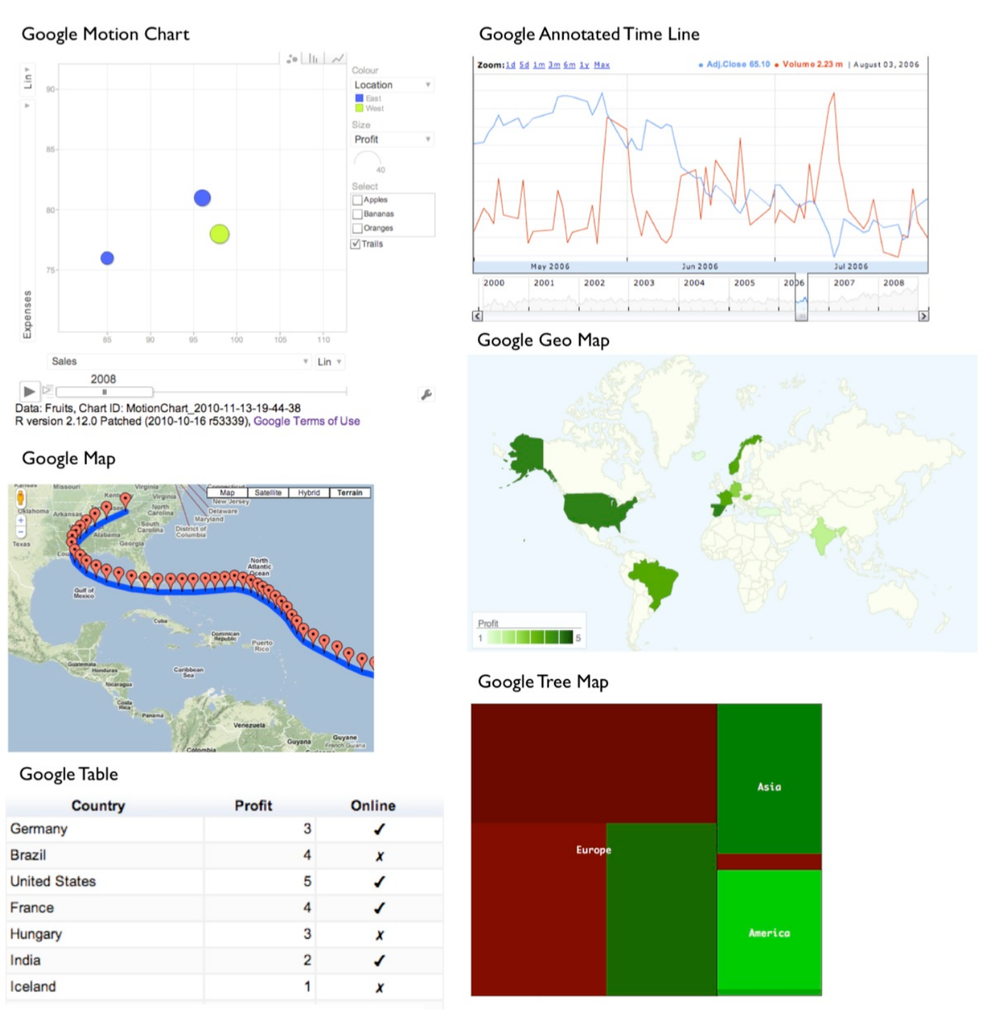

Figure 2: Screenshot of some of the outputs of demo(googleVis). Clockwise from top left: gvisMotionChart, gvisAnnotatedTimeLine, gvisGeoMap, gvisTreeMap, gvisTable, and gvisMap.

The individual functions of the [*googleVis*](https://CRAN.R-project.org/package=googleVis) package are documented in detail in the help pages and package [vignette](http://cran.r-project.org/web/packages/googleVis/vignettes/googleVis.pdf). Here we will cover only the principles of the package.

As an example we will show how to generate a Motion Chart as displayed in Figure 1. It works similarly for the other APIs. Further examples are covered in the demos of the [*googleVis*](https://CRAN.R-project.org/package=googleVis) package and on the project Google Code site.

The design of the visualisation functions is fairly generic. The name of the visualisation function is `’gvis’` followed by the chart type. Thus for the Motion Chart we have:

```r
gvisMotionChart(data, idvar = 'id',
    timevar = 'date', options = list())
```

Here `data` is the input `data.frame` and the arguments `idvar` and `timevar` specify the column names of the id variable and time variable for the plot, while display options are set in an optional list. The options and data requirements follow those of the Google Visualisation API and are documented in the help pages, see `help(’gvisMotionChart’)`.

The output of a [*googleVis*](https://CRAN.R-project.org/package=googleVis) function is a list of lists (a nested list) containing information about the chart type, chart id, and the html code in a sub-list split into header, chart, caption and footer.

The idea behind this concept is that users get a complete web page while at the same time they can extract only specific parts, such as the chart. This is particularly helpful if the package functions are used in solutions where the user wants to feed the visualisation output into other sites, or would like to embed them into rsp-pages, or use RApache or Google Gadgets.

The output of a [*googleVis*](https://CRAN.R-project.org/package=googleVis) function will be of class `"gvis"` and `"list"`. Generic print (`print.gvis`) and plot (`plot.gvis`) methods exist to ease the handling of such objects.

To illustrate the concept we shall create a motion chart using the `Fruits` data set.